# Order stars

[AMath 586, Spring Quarter 2019](http://staff.washington.edu/rjl/classes/am586s2019/) at the University of Washington. For other notebooks, see Index.html or the [Index of all notebooks on Github](https://github.com/rjleveque/amath586s2019/blob/master/notebooks/Index.html).

Plot the region of relative stability, also called the order star, for various 1-step methods.

The general approach is to apply the method to $u' = \lambda u$ with time step $k$ to obtain $U^{n+1} = R(z) U^n$, where $R(z)$ is a rational function of $z=k\lambda$ (a polynomial for an explicit method). Then evaluate $|R(z)/e^z|$ on a grid of points in the complex plane and do a filled contour plot that shows the regions where $|R(z)/e^z| \leq 1$.

```python
%pylab inline
```

```python
seterr(divide='ignore', invalid='ignore')  # suppress divide by zero warnings
```

```
{'divide': 'warn', 'over': 'warn', 'under': 'ignore', 'invalid': 'warn'}
```

```python
from ipywidgets import interact
```

```python
def plotOS(R, axisbox = [-10, 10, -10, 10], npts=500):
    """
    Compute |R(z)| over a fine grid on the region specified by axisbox
    and do a contour plot to show the region of absolute stability.
    """

    xa, xb, ya, yb = axisbox
    x = linspace(xa,xb,npts)
    y = linspace(ya,yb,npts)
    X,Y = meshgrid(x,y)
    Z = X + 1j*Y
    Rval = R(Z)
    Rrel = abs(Rval / exp(Z))

    # plot interior, exterior, as green and white:
    levels = [-1e9,1,1e9]
    CS1 = contourf(X, Y, Rrel, levels, colors = ('g', 'w'))

    # plot boundary as a black curve:
    CS2 = contour(X, Y, Rrel, [1,], colors = ('k',), linewidths = (2,))

    title('Order Star')
    grid(True)
    plot([xa,xb],[0,0],'k')  # x-axis
    plot([0,0],[ya,yb],'k')  # y-axis

    axis('scaled')  # scale x and y same so that circles are circular
    axis(axisbox)   # set limits
```

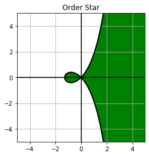

```python
R = lambda z: 1+z
plotOS(R, axisbox=[-5,5,-5,5])
```

## Theta method

```python
def plotOS_theta(theta):
    R = lambda z: (1. + (1-theta)*z) / (1-theta*z)
    figure(figsize=(6,6))
    plotOS(R, npts=200)  # use fewer points so interact works well
    title("Order star for theta-method with theta = %4.2f" % theta)
```

For $\theta=1/2$ this is the Trapezoid method, which is second order accurate, and so the order star has 3 sectors inside the region of relative stability near $z=0$:

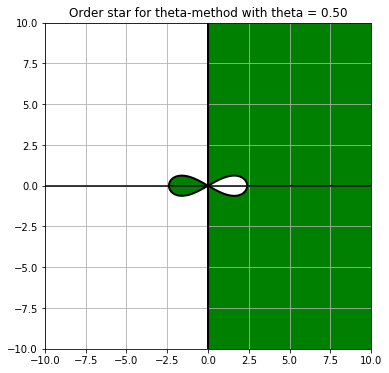

```python
plotOS_theta(0.5)
```

For all other $\theta$, the method is only first order accurate and there are only 2 sectors inside/outside the order star near $z=0$:

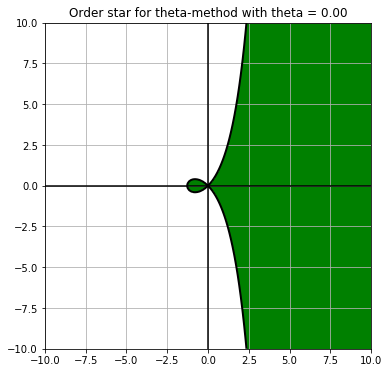

```python
interact(plotOS_theta, theta=(0,1,.1));
```

## Taylor series methods

For this class of methods we can easily increase the order and observe how the structure near the origin varies:

```python
def plotOS_TS(r):
    def R(z):
        # return Rz = 1 + z + 0.5z^2 + ... + (1/r!) z^r
        Rz = 1.
        term = 1.
        for j in range(1,r+1):
            term = term * z/float(j)
            Rz = Rz + term
        return Rz

    figure(figsize=(6,6))
    plotOS(R, npts=300)
    title('Taylor series method r = %i' % r)
```

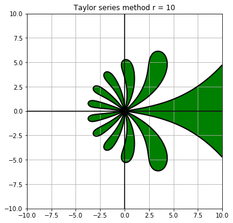

```python
interact(plotOS_TS, r=(1,20,1));
```

Note that the way this computation is done it is subject to a lot of cancellation near $z=0$, so plots above do not look correct in this region, particularly for $r>15$ or so -- there should be $r+1$ green sectors and $r+1$ white sectors approaching the origin.

Here's a better version for the particular case of high-degree Taylor series methods:

```python
def plotOS_TS(r):
    def R(z):
        # return Rz = 1 + z + 0.5z^2 + ... + (1/r!) z^r
        from math import factorial

        Rz = 1.
        term = 1.
        for j in range(1,r+1):
            term = term * z/float(j)
            Rz = Rz + term

        # for small z when r is large,
        # it's better to compute the remainder
        remainder = 0.
        term = 1./factorial(r)
        for j in range(r+1, 2*r):
            term = term * z/float(j)
            remainder = remainder + term
        remainder *= z**r

        # Define this so that contours of |R(z)/exp(z)| = 1
        # look right near origin:
        Rz_smallz = where(real(remainder/exp(z))>0., 0.5*exp(z), 2*exp(z))
        Rz = where(abs(z**(r+1)/factorial(r+1)) > 1e-10, Rz, Rz_smallz)

        return Rz

    figure(figsize=(6,6))
    plotOS(R, npts=500)
    title('Taylor series method r = %i' % r)
```

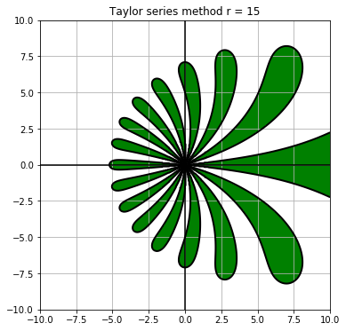

```python
interact(plotOS_TS, r=(1,30,1));
```